# Clustering

## Is there another way to build groups?

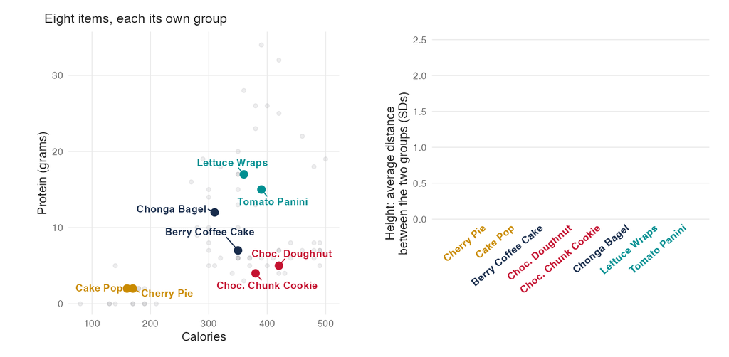

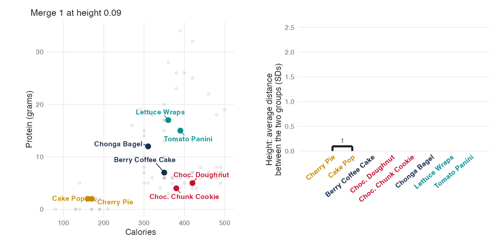

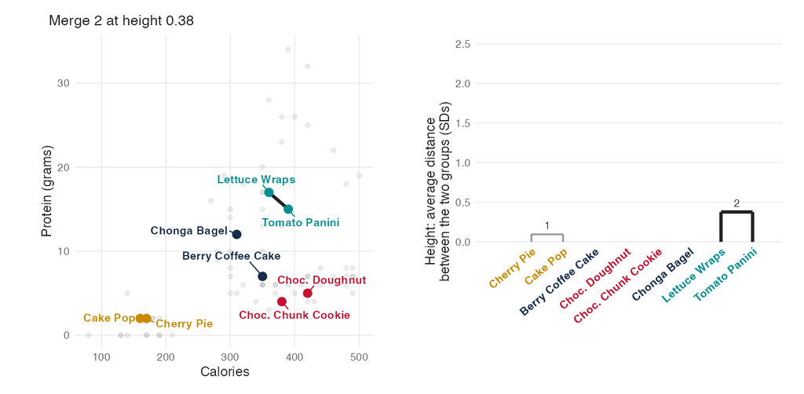

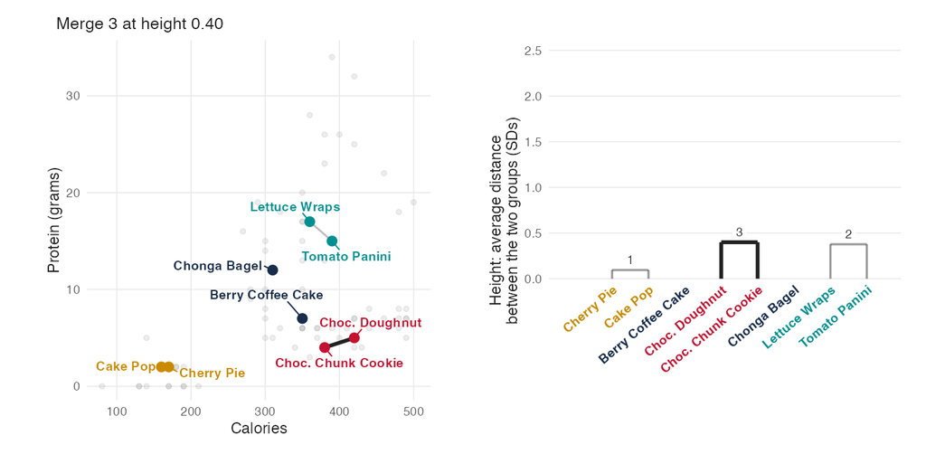

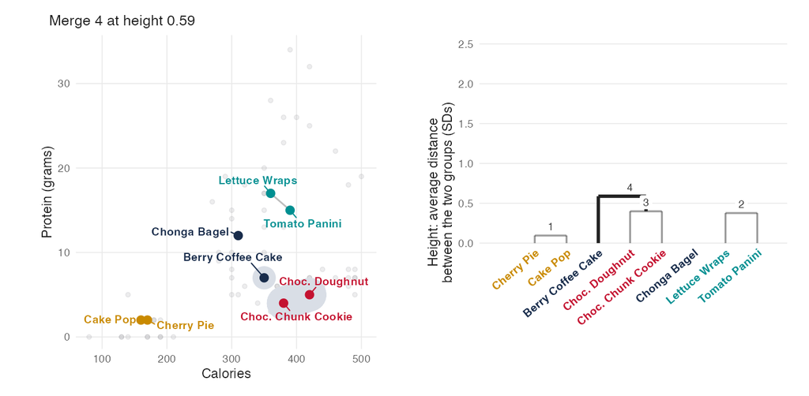

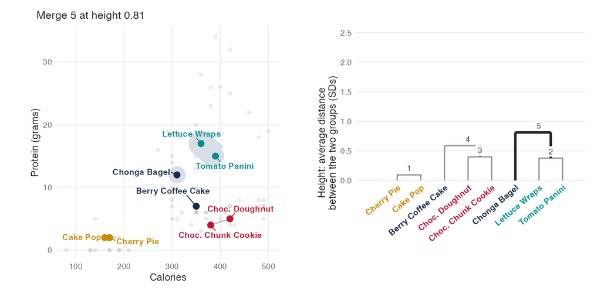

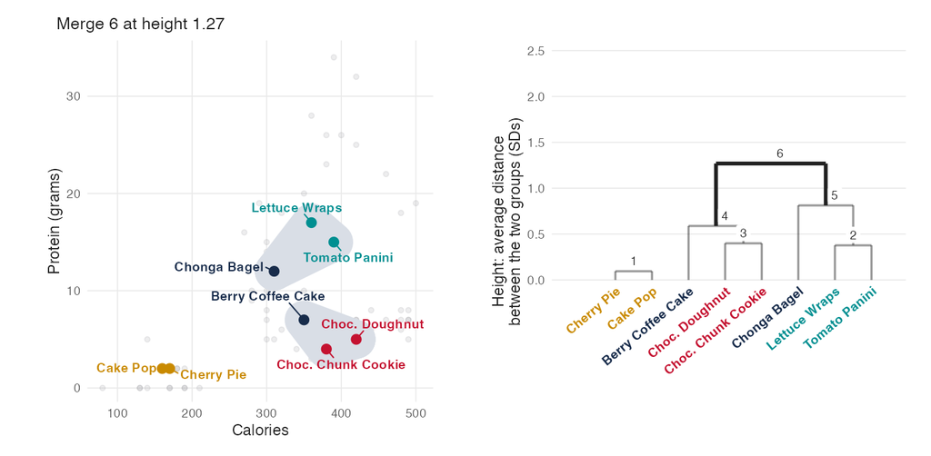

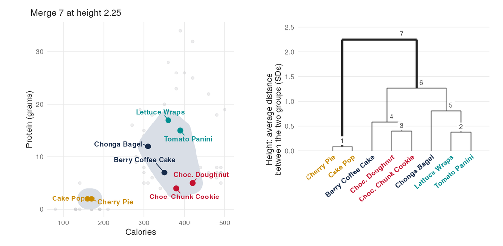

The picture shows calories and protein in their own units. On this slide the tree uses only these two numbers, in standard deviations, for eight items.

Each item starts as its own group. Which two would you join first?

**Hierarchical clustering** joins the two closest groups, again and again, and draws each join as a link in a tree, the **dendrogram**. With **average linkage**, the distance between two groups is the average of all distances between an item of one and an item of the other.

Merge 6: 3 items × 3 items = 9 distances, from 0.73 to 1.62; their average is 1.27, the height of the link.

## Where should we cut the tree?

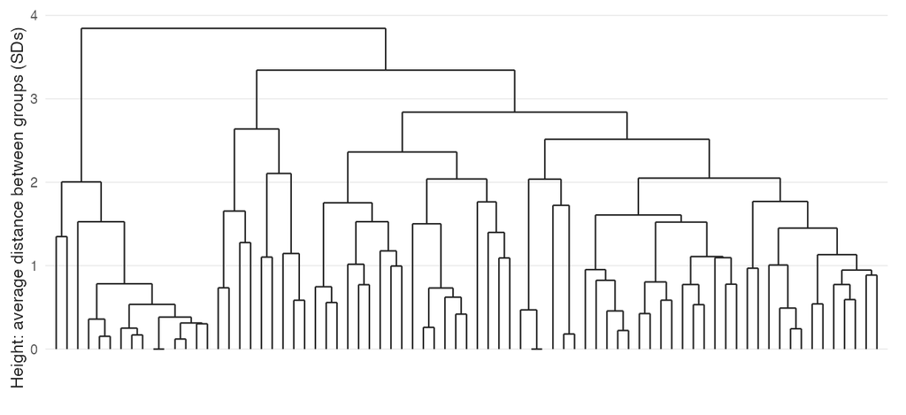

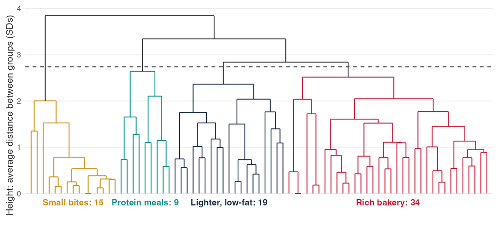

The tree uses all five numbers, in standard deviations, for all 77 items.

Cut the tree with one horizontal line. Where would you cut to get four groups?

Cut between the third and fourth highest links, at 2.74: four groups of 15, 19, 34 and 9 items. In R, cutree() does the cut.

## Do the two methods agree?

| K-means down, tree across | Small bites | Lighter, low-fat | Rich bakery | Protein meals |
| --- | --- | --- | --- | --- |
| Small bites | 15 | 0 | 0 | 0 |
| Lighter, low-fat | 0 | 16 | 3 | 0 |
| Rich bakery | 0 | 0 | 27 | 0 |
| Protein meals | 0 | 3 | 4 | 9 |

Will K-means and the tree put the same items together?

67 of 77 items are in the same group. The tree’s Protein meals group is smaller: 9 items against 16.

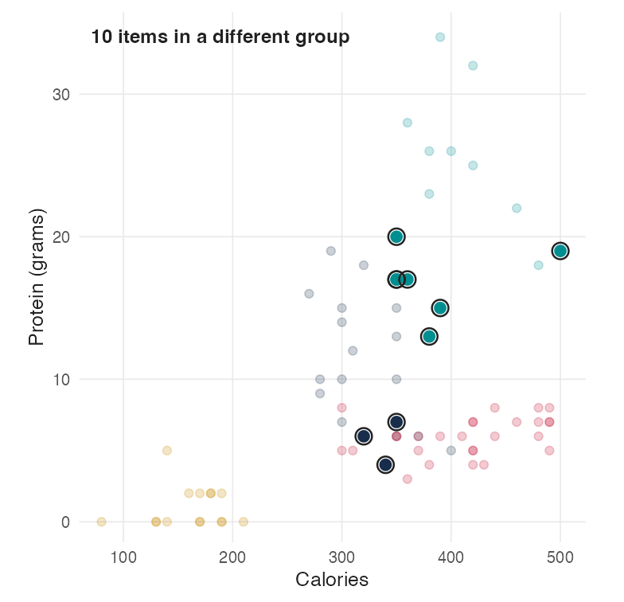

The picture shows calories and protein in their own units. The clustering itself uses all five numbers, in standard deviations.

## How do we run this in R?

```r
sb <- read.csv("starbucks_clean.csv")   # the menu file
X <- scale(sb[, c("calories", "fat", "carb", "fiber", "protein")])   # each number in SDs
set.seed(467)   # the same random starts for everyone
km <- kmeans(X, centers = 4, nstart = 20)   # K-means, best of 20 starts
km$size   # items in each group
round(aggregate(sb[, c("calories", "fat", "carb", "fiber", "protein")], list(group = km$cluster), mean), 1)
hc <- hclust(dist(X), method = "average")   # the tree, average linkage
table(kmeans = km$cluster, tree = cutree(hc, k = 4))   # cut at 4 groups and compare
```

```
[1] 27 19 15 16
  group calories  fat carb fiber protein
1     1    413.3 18.7 56.1   1.4     6.0
2     2    322.6  7.7 53.3   4.2    10.6
3     3    162.0  7.2 23.5   0.4     1.0
4     4    398.1 18.7 35.9   3.1    22.0
      tree
kmeans  1  2  3  4
     1  0 27  0  0
     2 16  3  0  0
     3  0  0 15  0
     4  3  4  0  9
```

R numbered the groups 1 to 4. Which number is Small bites?

## What should we check before trusting the groups?

1. **Are the numbers in different units? Put them in standard deviations first, or the number with the biggest spread decides alone.** In the file’s units, the groups were calorie bands. Slide 11
2. **Did you run many starts? One start can stop at a worse grouping.** On five numbers, one start found the best grouping in 53 of 100 tries; nstart = 20 found it all 100 times. Slide 9
3. **How many groups? Look at the elbow and the silhouette, then at what the team will use the groups for.** Here the elbow points to 4, and the silhouette nearly ties 2 and 4. Slides 12 and 13
4. **Do the names fit the means and the items in each group?** Type, which K-means never saw, backs them up: all 9 petites are Small bites. Slide 14
5. **Does a second method give the same groups?** The tree agrees on 67 of 77 items. Slide 17

## Can calories, fat, carb, fiber and protein sort the 77 items into a few groups that the team can name and use?

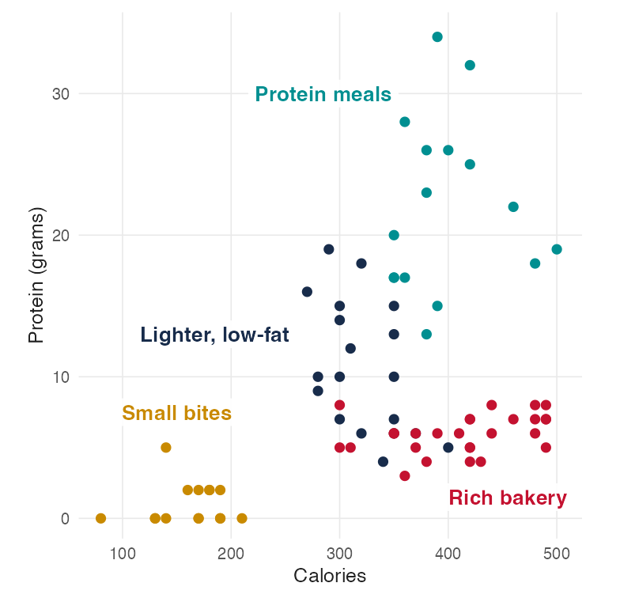

The picture shows calories and protein in their own units. The clustering itself uses all five numbers, in standard deviations.

1. **K-means puts items that are close on all five numbers in the same group.** Here: Small bites 15, Lighter, low-fat 19, Rich bakery 27, Protein meals 16.
2. **The unit decides what “close” means.** In standard deviations all five numbers count; in the file’s units, calories decide alone. Slide 11
3. **The number of groups is a judgment.** The elbow points to 4, the silhouette nearly ties 2 and 4, and four groups give the team names it can put on the board and in the app. Slides 12 and 13
4. **The groups show where the menu is thin.** Rich bakery is the largest group. No Small bites item has more than 5 g of protein, so a small, filling item is missing.

## What do the other linkages give?

Backup: from slides 15 and 17

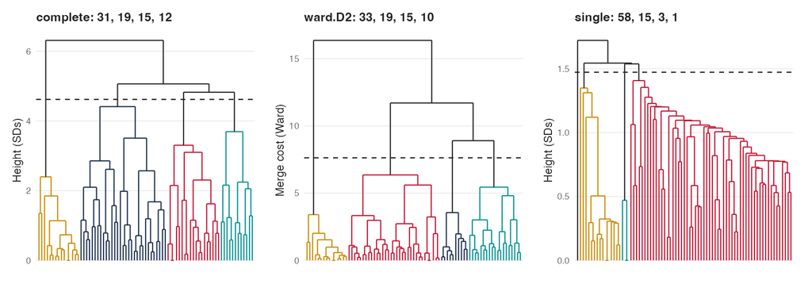

## What are the two groups at K = 2?

Backup: from slide 13

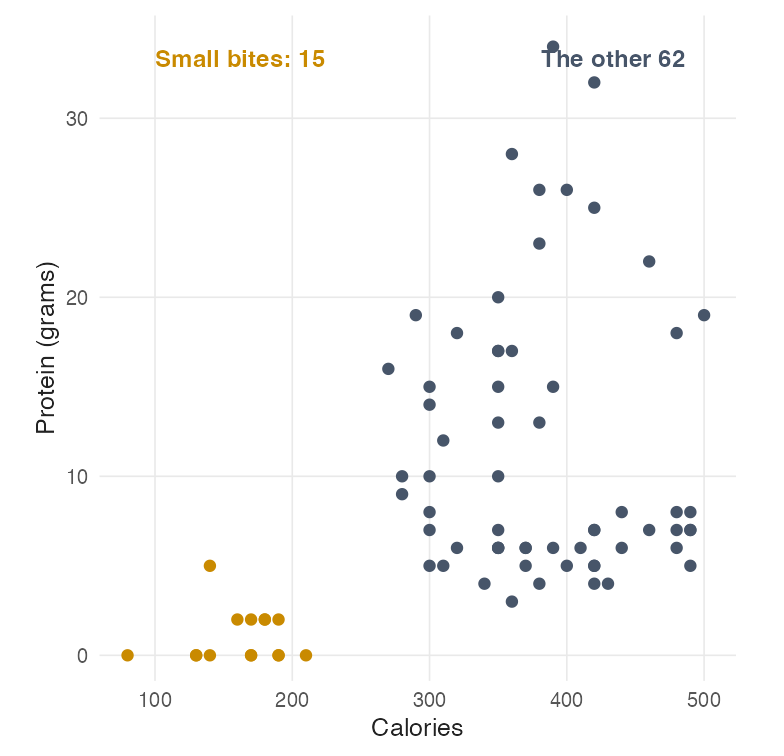

The picture shows calories and protein in their own units. The clustering itself uses all five numbers, in standard deviations.